fossil

# The rate of viral sex, dug back up.

18 results: 4 agree, 8 partly agree, 4 differ, 2 not attempted. The lost Python scripts were rewritten from the paper's text, the 1,753 env clones were fetched from GenBank and realigned with MUSCLE 3.6, and both analyses were run again.

See every result

## Fig. 2A

Fig. 2A. How often the haplotype that was missing at one sample turns up at the next, against the distance between the two sites. Red: the one haplotype recombination can build from the alleles already there. Green: haplotypes carrying an allele that was not there, which recombination cannot build.

Partly agrees

Published

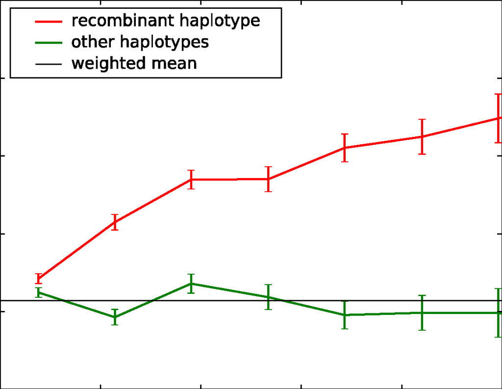

Our run

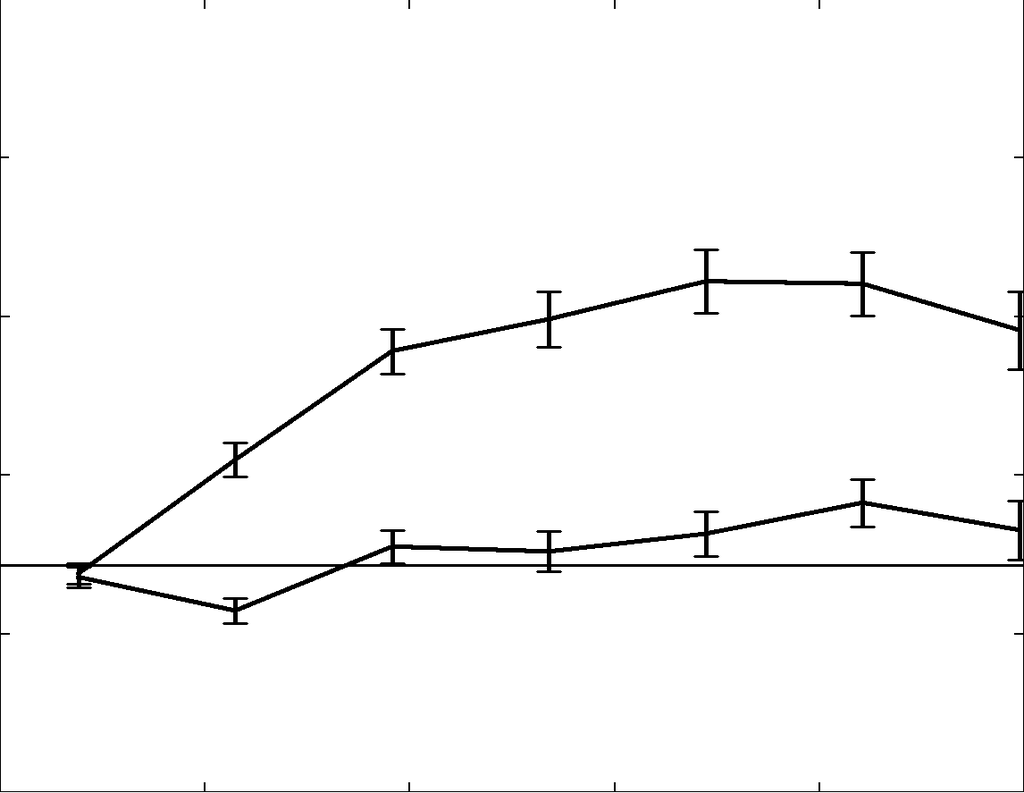

**Fig. 2A, missing haplotype against distance**

8 of 14 values, Partly agrees

## Fig. 2B

Fig. 2B. The same probability against distance times elapsed generations, with the fit of Eq. 5 in black. Its slope at zero and its intercept give the recombination rate.

Partly agrees

Published

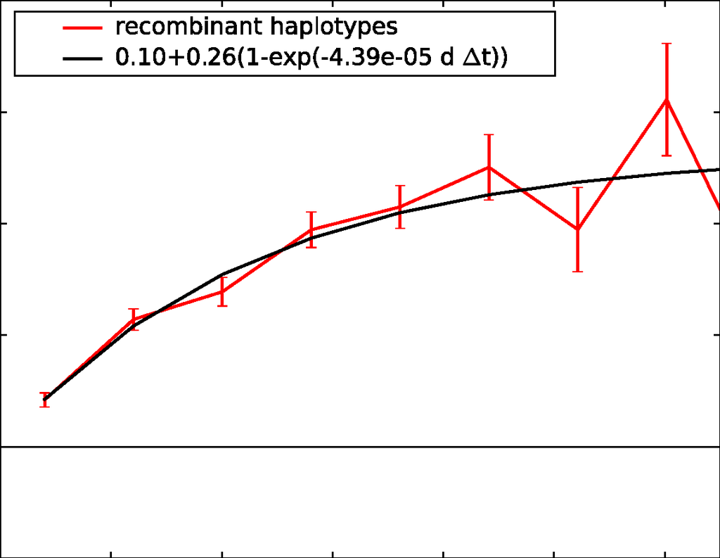

Our run

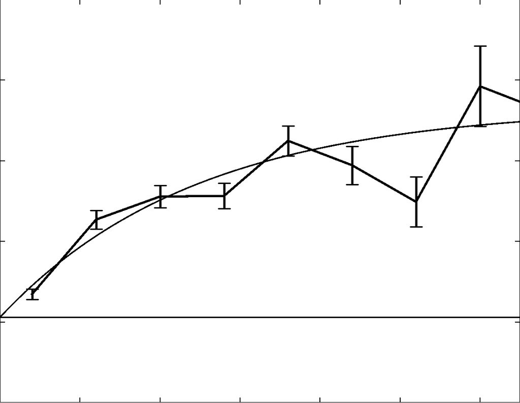

**Fig. 2B, missing haplotype against distance times time, with the fit**

7 of 9 values, Partly agrees

Seven of the nine points sit inside the published error bars; two (28,000 and 44,000 bp x generations) are 0.04 and 0.06 low. The bins hold 100 to 1,000 pairs, so single pairs moving in or out of the biallelic and gapless set shift them.

## Fig. 3

Fig. 3. The spread of the rate over 500 resamples of the eleven patients.

Differs

Published

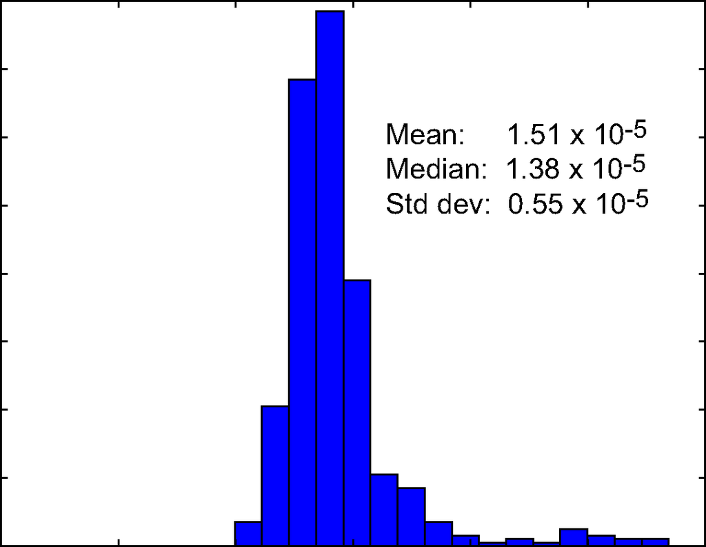

Our run

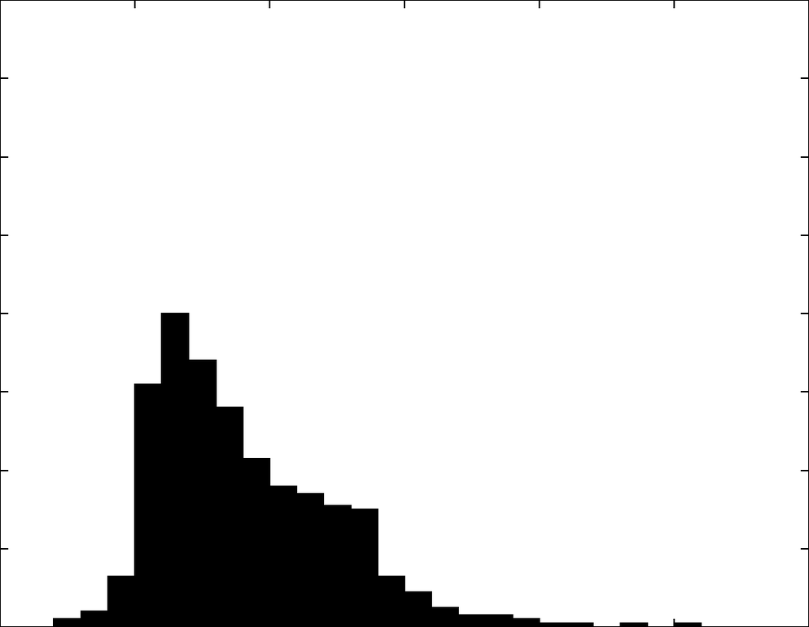

**Fig. 3, bootstrap distribution of the recombination rate**

32.4% within 2 px, Differs

**Fig. 3, the printed mean, median and standard deviation of the bootstrap**

0 of 3 values, Differs

On the published axes our histogram sits about 0.5e-05 to the left of the published one: its peak is at 9 to 10 x 10^-6 where the published peak is at 13 to 15. A wrong-input control (a flat distribution) now scores better than our histogram, so the panel differs. Our bootstrap sits at mean 0.92e-05, median 0.83e-05 and standard deviation 0.39e-05, against 1.51, 1.38 and 0.55. The distribution has the paper's shape and spread but a lower centre, which follows from rho itself.

## Fig. 4

Fig. 4. How fast allele frequencies change between consecutive samples, as cumulative distributions: non-synonymous, synonymous, and synonymous at least 100 bp from a fast non-synonymous site. The inset holds the counts behind them, on a log scale.

Partly agrees

Published

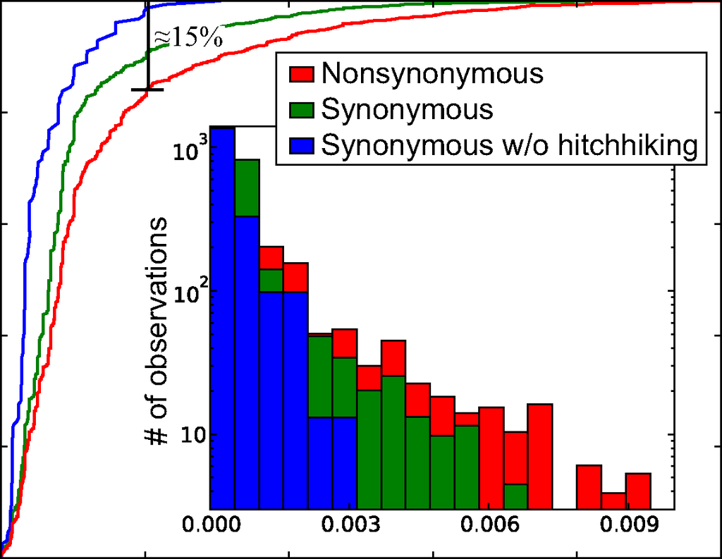

Our run

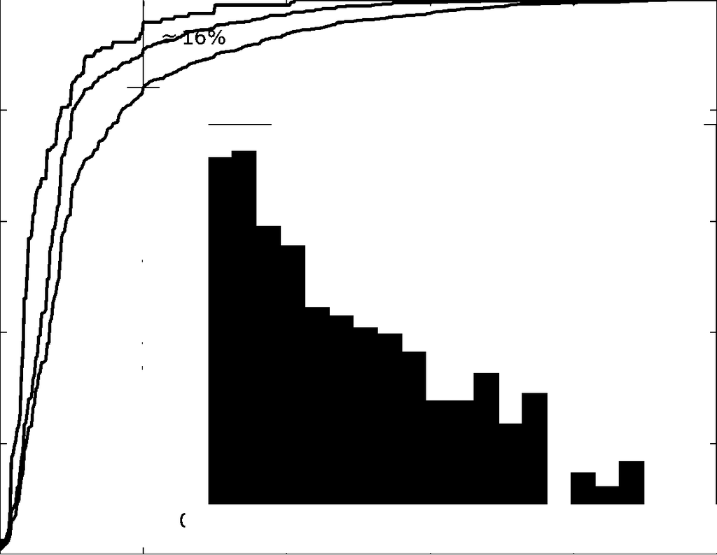

**Fig. 4, the three cumulative distributions**

15 of 18 values, Partly agrees

**Fig. 4 inset, the observation counts per bin**

15 of 32 values, Partly agrees

## Every result

Every figure, number and claim of the paper. A point of Figure 2 agrees when it is inside the published error bar plus ours; a point of Figure 4 when it is within two standard errors.

Result

Verdict

Measure

Why

Fig. 1, how recombination makes the missing haplotype

Not attempted

A drawing of two sites and four haplotypes. It shows no data.

Fig. 2A, missing haplotype against distance

Partly agrees

8 of 14 values

- recombinant 38 bp: paper 0.142, ours **0.138**
- recombinant 114 bp: paper 0.214, ours **0.21**
- recombinant 190 bp: paper 0.269, ours **0.278**
- recombinant 267 bp: paper 0.27, ours **0.298**
- recombinant 343 bp: paper 0.31, ours **0.322**
- recombinant 420 bp: paper 0.324, ours **0.321**
- recombinant 496 bp: paper 0.348, ours **0.291**
- other 38 bp: paper 0.124, ours **0.136**
- other 114 bp: paper 0.093, ours **0.114**
- other 190 bp: paper 0.136, ours **0.155**
- other 267 bp: paper 0.125, ours **0.152**
- other 343 bp: paper 0.095, ours **0.163**
- other 420 bp: paper 0.094, ours **0.182**
- other 496 bp: paper 0.083, ours **0.165**

Fig. 2B, missing haplotype against distance times time, with the fit

Partly agrees

7 of 9 values

- 4140 bp x gen: paper 0.138, ours **0.134**
- 12024 bp x gen: paper 0.217, ours **0.227**
- 20022 bp x gen: paper 0.239, ours **0.256**
- 28076 bp x gen: paper 0.299, ours **0.256**
- 36073 bp x gen: paper 0.323, ours **0.325**
- 44127 bp x gen: paper 0.354, ours **0.294**
- 52125 bp x gen: paper 0.295, ours **0.249**
- 61540 bp x gen: paper 0.388, ours **0.392**
- 64149 bp x gen: paper 0.33, ours **0.362**

Seven of the nine points sit inside the published error bars; two (28,000 and 44,000 bp x generations) are 0.04 and 0.06 low. The bins hold 100 to 1,000 pairs, so single pairs moving in or out of the biallelic and gapless set shift them.

Fig. 2B legend: c0, c1 and c2 of the fit

Agrees

3 of 3 values

- c0: paper 0.10, ours **0.106**
- c1: paper 0.26, ours **0.261**
- c2: paper 4.39e-05, ours **4.06e-05**

Methods: <M pA pB> ~ 0.93 measured in the data

Differs

0 of 1 values

- <M pA pB>: paper 0.93, ours **1.19**

Ours is 1.19 against the paper's 0.93. This one number sets the rate through rho = c1 c2 / (<M pA pB> - c0): with the paper's 0.93 our fit gives 1.3e-05 against its 1.4e-05.

Abstract and Eq. 3: rho = 1.4 +- 0.6 x 10^-5 per site and generation

Agrees

1 of 1 values

- rho (per site and generation): paper 1.4e-05, ours **9.79e-06**

rho = 9.8e-06 against 1.4e-05, inside the paper's own one standard deviation, which is the tolerance the paper gives the number. The gap follows from <M pA pB>: with the paper's 0.93 our fit gives 1.3e-05.

Fig. 3, the printed mean, median and standard deviation of the bootstrap

Differs

0 of 3 values

- mean: paper 1.51e-05, ours **9.27e-06**
- median: paper 1.38e-05, ours **8.34e-06**
- standard deviation: paper 0.55e-05, ours **3.93e-06**

Our bootstrap sits at mean 0.92e-05, median 0.83e-05 and standard deviation 0.39e-05, against 1.51, 1.38 and 0.55. The distribution has the paper's shape and spread but a lower centre, which follows from rho itself.

Fig. 3, bootstrap distribution of the recombination rate

Differs

32.4% within 2 px

On the published axes our histogram sits about 0.5e-05 to the left of the published one: its peak is at 9 to 10 x 10^-6 where the published peak is at 13 to 15. A wrong-input control (a flat distribution) now scores better than our histogram, so the panel differs.

Fig. 4, the three cumulative distributions

Partly agrees

15 of 18 values

- nonsynonymous at 0.0005: paper 0.281, ours **0.298**
- nonsynonymous at 0.001: paper 0.629, ours **0.652**
- nonsynonymous at 0.0015: paper 0.757, ours **0.765**
- nonsynonymous at 0.002: paper 0.828, ours **0.841**
- nonsynonymous at 0.0025: paper 0.87, ours **0.874**
- nonsynonymous at 0.003: paper 0.895, ours **0.9**
- nonsynonymous at 0.0035: paper 0.916, ours **0.917**
- nonsynonymous at 0.004: paper 0.932, ours **0.939**
- synonymous at 0.0005: paper 0.342, ours **0.354**
- synonymous at 0.001: paper 0.763, ours **0.792**
- synonymous at 0.0015: paper 0.859, ours **0.869**
- synonymous at 0.002: paper 0.895, ours **0.91**
- synonymous at 0.004: paper 0.971, ours **0.974**
- synonymous_no_hitchhiking at 0.0005: paper 0.683, ours **0.646**
- synonymous_no_hitchhiking at 0.001: paper 0.864, ours **0.846**
- synonymous_no_hitchhiking at 0.0015: paper 0.936, ours **0.913**
- synonymous_no_hitchhiking at 0.002: paper 0.979, ours **0.959**
- synonymous_no_hitchhiking at 0.0025: paper 0.994, ours **0.969**

Fig. 4 inset, the observation counts per bin

Partly agrees

15 of 32 values

- nonsynonymous, bin 2: paper 197.8, ours **268**
- nonsynonymous, bin 3: paper 152.2, ours **195**
- nonsynonymous, bin 4: paper 49.3, ours **72**
- nonsynonymous, bin 5: paper 52.9, ours **63**
- nonsynonymous, bin 6: paper 29.5, ours **52**
- nonsynonymous, bin 7: paper 44.1, ours **47**
- nonsynonymous, bin 8: paper 22.3, ours **35**
- nonsynonymous, bin 9: paper 18, ours **16**
- nonsynonymous, bin 10: paper 13.9, ours **16**
- nonsynonymous, bin 11: paper 15.2, ours **25**
- nonsynonymous, bin 12: paper 10.3, ours **11**
- nonsynonymous, bin 13: paper 16, ours **18**
- nonsynonymous, bin 15: paper 6, ours **5**
- nonsynonymous, bin 16: paper 3.9, ours **4**
- nonsynonymous, bin 17: paper 5.3, ours **6**
- synonymous, bin 1: paper 793.3, ours **447**
- synonymous, bin 2: paper 137.7, ours **68**
- synonymous, bin 4: paper 47.4, ours **26**
- synonymous, bin 5: paper 33.6, ours **16**
- synonymous, bin 6: paper 19.9, ours **12**
- synonymous, bin 7: paper 25.1, ours **12**
- synonymous, bin 8: paper 13.1, ours **10**
- synonymous, bin 9: paper 9.7, ours **4**
- synonymous, bin 10: paper 11.3, ours **4**
- synonymous, bin 12: paper 4.4, ours **1**
- synonymous_no_hitchhiking, bin 0: paper 1312.3, ours **128**
- synonymous_no_hitchhiking, bin 1: paper 320.6, ours **38**
- synonymous_no_hitchhiking, bin 2: paper 95.8, ours **13**
- synonymous_no_hitchhiking, bin 3: paper 95.8, ours **8**
- synonymous_no_hitchhiking, bin 4: paper 12.9, ours **2**
- synonymous_no_hitchhiking, bin 5: paper 12.9, ours **4**
- observations, non-synonymous: paper 2400, ours **2541**

Results: 15% of non-synonymous polymorphisms change faster than 0.002 per generation

Partly agrees

4 of 6 values

- non-synonymous faster than 0.002 per generation: paper 0.15, ours **0.159**
- more fast non-synonymous than fast synonymous polymorphisms: paper yes, ours **yes**
- share of synonymous faster than 0.002 per generation: paper 0.105, ours **0.09**
- fastest non-synonymous change: paper 0.01, ours **0.011**
- share of synonymous without hitch-hiking beyond 0.003 per generation: paper 0.00, ours **0.01**
- selection coefficient of the top 15% (s >= 4 dp/dt): paper 0.008, ours **0.0083**

Four of the five counted fields come back: more fast non-synonymous than synonymous polymorphisms, the synonymous share above 0.002 per generation, the fastest non-synonymous change (0.011 against 0.01) and the selection coefficient of the top sixth (0.0083 against 0.008). Two of our 195 synonymous observations without hitch-hiking lie beyond 0.003 per generation, where the paper reports none. The paper's own Figure 4 puts its non-synonymous share above 0.002 at 17.2 percent where its text says about 15; ours is 15.9, between the two, so that field is excepted.

Results: the two Kolmogorov-Smirnov p values

Partly agrees

2 of 3 values

- p, non-synonymous vs synonymous (< 1e-13): paper yes, ours **yes**
- p, non-synonymous vs synonymous without hitch-hiking (< 1e-25): paper yes, ours **no**
- Kolmogorov-Smirnov D, vs synonymous: paper 0.14, ours **0.14**

The first p value comes back (7.6e-14, below 1e-13) and the Kolmogorov-Smirnov D matches at 0.14. The second is 3.6e-21 against the paper's bound of 1e-25, because our synonymous set without hitch-hiking holds 195 observations and D is 0.36, where the published inset holds about 1,850.

Results: the other-haplotype curve does not rise with distance

Partly agrees

1 of 2 values

- rise of the other-haplotype curve over 500 bp: paper 0.0, ours **0.054**
- flatter than the recombinant curve: paper yes, ours **yes**

Our other-haplotype curve is far flatter than the recombinant curve, as the paper says, but it rises by 0.054 over 500 bp with a standard error of 0.017, so it is not consistent with no distance dependence. The published curve falls by 0.041 over the same range.

Discussion numbers recomputed from the paper's own rho

Agrees

Discussion: factor below template switching, coinfection, sweep region, distance between sweeps

Partly agrees

3 of 4 values

- template switching / rho: paper 2e1, ours **31**
- probability of coinfection: paper 1e-1, ours **0.065**
- sweep region [bp]: paper 2e2, ours **220**
- distance between sweeping loci [bp]: paper 4e2, ours **440**

Methods: the allele-count cutoff at 2 or 4 gives similar results

Differs

0 of 1 values

- the cutoff at two and at four alleles gives a similar rate: paper yes, ours **no**

The paper makes one claim about both cutoffs. At two alleles rho is 1.3e-05, within a factor of 1.4 of our 9.8e-06, but at four the fit runs into its bound (c1 = 1.0, c2 = 5.4e-06) and gives 4.1e-06, a factor of 2.4 away, so the claim does not hold on our run. The paper gives no numbers for either.

The authors' scripts

Not attempted

The analysis scripts were never released. The paper says only that scripting and plotting were done in Python with NumPy and Matplotlib, and no archive, laboratory page or later repository of the group holds them.

Python package hivrecomb and its tutorial

Agrees

## What came back

**Fig. 2A**

**Fig. 2B**

Seven of the nine points inside the published error bars, and a fit of 0.106 + 0.261 (1 - exp(-4.06e-05 x)) against the published 0.10 + 0.26 (1 - exp(-4.39e-05 x)), every constant inside the fit's own spread.

**The rate**

9.8e-06 per site and generation, inside the 1.4 +- 0.6 x 10^-5 the paper prints.

**Fig. 4**

15 of the 18 readable points of the three cumulative curves, and the non-synonymous counts of the inset in 9 of its 15 readable bins.

**Selection**

16 percent of non-synonymous polymorphisms faster than 0.002 per generation, a fastest change of 0.011, and a selection coefficient of 0.0083 for the top sixth.

**The scripts**

The method as the Python package hivrecomb, written from the paper's text and checked against a brute-force enumeration.

## What stayed buried

- The average M pA pB: the paper reports 0.93, and the five conventions we tried give 1.04 to 1.60. It divides the rate, so it sets the gap.
- The observation counts behind Figure 4: the paper's inset holds about 1,850 synonymous observations away from hitch-hiking, where our filter leaves 195 of 1,060.
- The bins of Figures 2 and 3, the fit's weights and the bootstrap seed: none is stated, so they were read from the published panels.
- Which sequences were used: adding the 212 Shriner 2004 clones that LANL's set 1 holds beyond the paper's accession list moves the rate further away, so they were left out.

The paper's two findings come back. Recombination rises with the distance between sites and with elapsed time, and the fit of Figure 2B comes back inside its own uncertainty, as does the rate: 9.8e-06 per site and generation against 1.4e-05, within the standard deviation the paper prints. About 16 percent of non-synonymous polymorphisms change faster than 0.002 per generation, against the paper's 15, and the synonymous ones do not. Four things differ: the measured average M pA pB (1.19 against 0.93), which is what pulls the rate low; the bootstrap distribution of Figure 3 and its printed statistics, which sit about 40 percent low with it; and the allele-count cutoff, where the paper's claim of similar results does not hold at four alleles on our run.

## What we matched

How each part of the paper's method was rebuilt.

**Data**

1,753 HIV-1 env C2-V5 clones of 11 patients from the paper's four GenBank accession ranges, with the sampling month from the clone name and, for patients 4 and 10, from LANL's clinical file.

**Alignment**

Translate, align each patient with MUSCLE 3.6 built from its own source, put the codons back.

**Recombination**

Pairs of biallelic gapless sites with three of four haplotypes and each allele seen three times; does the fourth turn up at the next sample?

**The rate**

Weighted least squares fit of c0 + c1 (1 - exp(-c2 d dt)), then rho = c1 c2 / (M pA pB - c0), with 500 resamples of the patients.

**Selection**

The rate of allele frequency change at each site, classed by the consensus codon, with the paper's 100 bp hitch-hiking filter and a Kolmogorov-Smirnov test.